# **Ensayo Regresión lineal**

### Juan Felipe Salamanca Garzón

## Introducción

```python
from IPython.display import Image
```

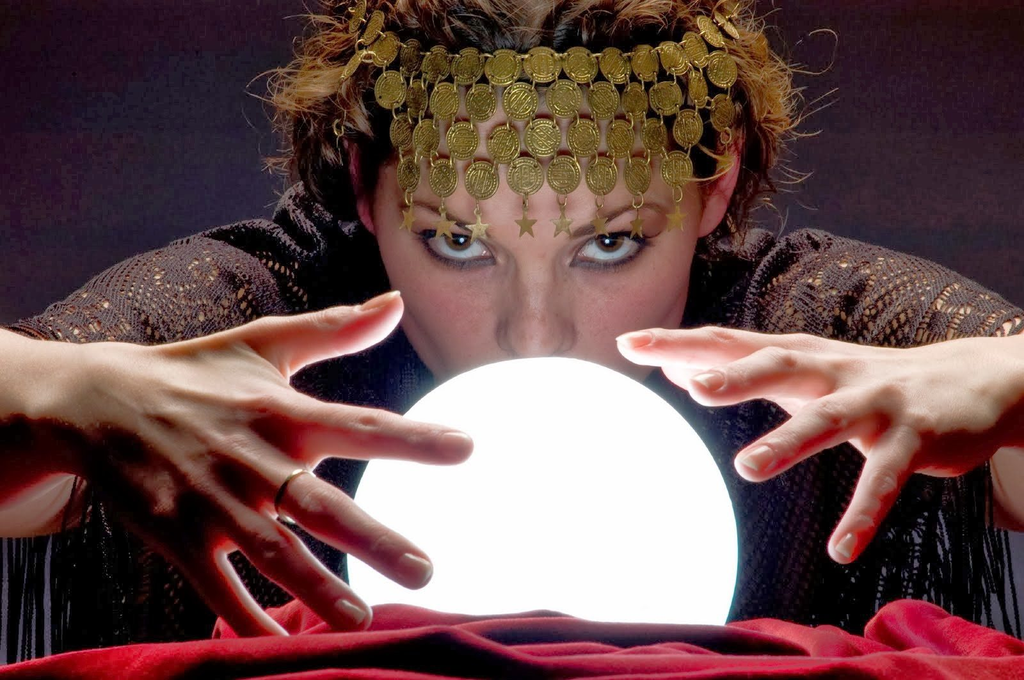

```python
Image("C:/Users/Juan Felipe Salamanc/Desktop/brujo.jpg",width=300)
```

Se dice que en general cualquier modelo de regresión, en particular un modelo de regresión lineal, se usa fundamentalmente para estimación, predicción y comprobación de supuestos. Pero para las personas ajenas a la estadística, se suele pensar que cuando se tiene un modelo, ya se tiene una bola de cristal en donde dados ciertos valores, mágicamente se puede obtener el valor de la variable en cuestión y se piensa que esto siempre será así y que sin pérdida de generalidad este será el valor.

Pero si esto fuera tan sencillo, no sería tan necesario todo el bagaje teórico asociado, en el cual precisamente entre otras cosas, es indispensable cuantificar los errores de predicción del modelo, lo lo que es lo mismo a ver cuál es la similitud del modelo generado, con respecto a los datos que ya se tienen, así como la utilidad del modelo a través de ciertos coeficientes, llamados coeficientes de bondad de ajuste. Y por si esto no fuera poco, el modelo debe cumplir con ciertos supuestos asociados a los residuales del modelo, los cuales se abordarán más adelante.

Todo esto, con lo dicho anteriormente puede parecer bastante complejo, pero si todos estos supuestos asociados se cumplen, se obtendrá un buen modelo, que matemáticamente no tiene una estructura muy simple, que incluso se puede asemejar a la bola de cristal ya mencionada.

## Breve reseña histórica

[figure not shown]

```python
from IPython.core.display import HTML
Image(url= "https://estaticos-cdn.elperiodico.com/clip/60619ef5-94bc-4b7d-893b-ed92e867671b_alta-libre-aspect-ratio_default_0.jpg",
     width=400)
```

El primer método de regresión, fue el de mínimos cuadrados, el cual se abordará más adelante, en un estudio publicado por Legendre en 1805 y por Gauss en 1809, en el que querían determinar la órbita de los cuerpos celestes alrededor del sol. En un principio estaban interesados por los cometas, pero después realizaron los correspondientes estudios con algunos planetas menores descubiertos, hasta que finalmente, en 1825, publicó una versión del teorema de Gauss-Markov, el cuál establece la exitencia y forma de cálculo de los estimadores MELI; es decir, los mejores estimadores lineales insesgados de mínima varianza.

Posteriormente, ya en el año 1889, fue introducido por primera vez el término regresión, por parte del estadístico Francis Galton en su trabajo *Natural Inheritance*, en donde se buscaba si la estatura de los hijos, podía ser explicada por medio de la estatura de los padres. Su trabajo fue extendido en un contexto estadístico más general por Udny Yule y Karl Pearson, en donde por primera vez se observó que la distribución conjunta de la variable respuesta y de las variables explicativas es normal multivariada. Pero posteriormente, en 1922, Fisher teoriza sobre el supuesto que la distribución condicional de la variable dependiente dadas las variables independientes es Gaussiana, pero que no necesariamente lo era la distribución conjunta.

Posteriormente, con la innovación de las computadoras, el cálculo de los parámetros de la regresión se optimizó, pasando de un tiempo en el cálculo de más de 24 horas antes de la década de los 70's, a uno de unos pocos segundos en la actualidad.

Para más información, consultar:

[Presentación interactiva sobre la historia de la regresión lineal](https://prezi.com/qpxysldecq4u/regresion-lineal/)\ [Breve historia de la regresión lineal](https://es.wikipedia.org/wiki/An%C3%A1lisis_de_la_regresi%C3%B3n)

## Planteamineto del algoritmo

La forma general de la regresión lineal, está dada por la expresión:

\begin{equation*} Y=X\beta + \epsilon \end{equation*}

En donde $Y$ corresponde al vector que reúne a los valores correspondientes a la variable respuesta, $X$ corresponde a una matriz que reune a los valores de las variables explicativas para todos los individuos, $\beta$ es un vector que reune a los parámetros del modelo y por su parte $\epsilon$ corresponde a un vector que reúne a los valores del error de predicción para todos los individuos.

De esta forma, no es difícil observar que para el i-ésimo individuo, en donde se tienen k variables explicativas, se tiene el siguiente modelo: \begin{equation*} y_i=\beta_1x_{i1}+\beta_2x_{i2}+...+\beta_kx_{ik}+\epsilon_i \end{equation*}

Para realizar la estimación de los parámetros asociados al modelo, se utilizará el método de los mínimos cuadrados, el cual consiste en minimizar los errores de predicción al cuadrado.

Del planteamiento inicial, se tiene que: \begin{equation*} \epsilon = Y-X\beta \end{equation*}

Y por tanto a su vez se tiene que: \begin{equation*} \epsilon^T\epsilon= (Y-X\beta)^T(Y-X\beta)=Y^TY-Y^TX\beta-\beta^TX^TY+\beta^TX^TX\beta=Y^TY-2\beta^TX^TY+\beta^TX^TX\beta \end{equation*}

Sea $L=\epsilon^T\epsilon$. De la teoría de cálculo diferencial se sabe que un mínimo local se encuentra cuando la primera derivada, con respecto a los parámetros de interés es igual a cero. Realizando la derivada, se obtiene que: \begin{equation*} \frac{\partial L}{\partial \beta}=-2X^TY+2X^TX\beta \end{equation*}

Igualando a cero, se obtiene que:

\begin{equation*} -2X^TY+2X^TX\hat\beta=0 \Rightarrow -X^TY+X^TX\hat\beta=0 \Rightarrow X^TX\hat\beta= X^TY \end{equation*}

En donde finalmente se obtiene que:

\begin{equation*} \hat\beta = (X^TX)^{-1}X^TY \end{equation*}

En donde se debe garantizar la condición de que $X^TX$ sea una matriz de rango completo. En caso contrario, se debe trabajar con una inversa generalizada.

Para chequear la bondad de ajuste del modelo, se planteará la prueba de hipótesis, en donde se tiene:

Para este caso, se tendrá en cuenta que bajo $H_0$ cierta, se puede ver que:

\begin{equation*} SCM=Y^T(H_x-\frac{1}{n}J)Y \sim \chi^2_{(k)} \end{equation*}\begin{equation*} SCE=Y^T(I-H_x)Y \sim \chi^2_{(n-k-1)} \end{equation*}

Donde las expresiones $SCM$ y $SCE$ se conocen como las sumas de cuadrados del modelo y de los residuales, respectivamente, y a su vez $H_x=X(X^TX)^{-1}X^T$ y $J=11^T$, es una martriz de 1's de tamaño nxn. En donde nuevamente bajo el supuesto, se tiene que el estadístico:

\begin{equation*} F_c=\frac{CMM}{CME}\sim F_{(k,n-k-1)} \end{equation*}

En donde $CMM$ y $CME$ corresponden al Cuadrado Medio del Modelo y al Cuadrado Medio del Error, respectivamente, tales que $CMM=\frac{SCM}{k}$ y $CME=\frac{SCE}{n-k-1}$.

De esta forma, se puede construir la tabla de Análisis de Varianza (Anova) de la siguiente forma:

| Fuentes de variación | Grados de libertad | SC | CM | F |
| --- | --- | --- | --- | --- |
| Modelo | k | SCM | CMM | $F_c$=CMM/CME |
| Error | n-k-1 | SCE | CME |  |
| Total | n-1 | SCT |  |  |

Se rechaza $H_0$ a un nivel de significancia $\alpha$ si $F_c>F_{(k,n-k-1,1-\alpha)}$, donde $F_{(k,n-k-1,1-\alpha)}$ corresponde al percentil $1-\alpha$ de una distribución $F$ con un $k$ grados de libertad en el numerador y $n-k-1$ grados de libertad en el denominador

Para que el modelo además sea apropiado, se deben cumplir los siguientes supuestos:

I) $E(\epsilon_i)=0$, para todo i\ II)$Var(\epsilon_i)=\sigma^2$, para todo i\ III)$\epsilon_i \sim N(0,\sigma^2)$, para todo i\ IV)$Cov(\epsilon_i,\epsilon_{i'})=0$, para todo i,i'\ V)$Cov(X_j,X_{j'})=0$, para todo i,i'\ VI)$Cov(\epsilon_i,X_{ij})=0$ pata todo i,j

## Ejemplo práctico

Se comenzará por importar las librerías necesarias para realizar el correspondiente modelo

```python
import numpy as np
import pandas as pd
import seaborn as sb
import matplotlib.pyplot as plt
import statsmodels.api as sm
import statsmodels.formula.api as smf
%matplotlib inline
from mpl_toolkits.mplot3d import Axes3D
from matplotlib import cm
from statsmodels.formula.api import ols
plt.rcParams['figure.figsize'] = (16, 9)
plt.style.use('ggplot')
from sklearn import linear_model
from sklearn.metrics import mean_squared_error, r2_score
```

Posteriormente, se procede a leer el conjunto de datos

```python
data = pd.read_csv("C:/Users/Juan Felipe Salamanc/Documents/Minería de datos/Car details v3.csv")
data.shape
```

```
(8128, 13)
```

Como se puede observar, este conjunto de datos tiene 8128 individuos con trece variables, en donde a continuación se pueden ver los primeros datos

```python
data.head()
```

|  | name | year | selling_price | km_driven | fuel | seller_type | transmission | owner | mileage | engine | max_power | torque | seats |
| --- | --- | --- | --- | --- | --- | --- | --- | --- | --- | --- | --- | --- | --- |
| 0 | Maruti Swift Dzire VDI | 2014 | 450000 | 145500 | Diesel | Individual | Manual | First Owner | 23.4 kmpl | 1248 CC | 74 bhp | 190Nm@ 2000rpm | 5.0 |
| 1 | Skoda Rapid 1.5 TDI Ambition | 2014 | 370000 | 120000 | Diesel | Individual | Manual | Second Owner | 21.14 kmpl | 1498 CC | 103.52 bhp | 250Nm@ 1500-2500rpm | 5.0 |
| 2 | Honda City 2017-2020 EXi | 2006 | 158000 | 140000 | Petrol | Individual | Manual | Third Owner | 17.7 kmpl | 1497 CC | 78 bhp | 12.7@ 2,700(kgm@ rpm) | 5.0 |
| 3 | Hyundai i20 Sportz Diesel | 2010 | 225000 | 127000 | Diesel | Individual | Manual | First Owner | 23.0 kmpl | 1396 CC | 90 bhp | 22.4 kgm at 1750-2750rpm | 5.0 |
| 4 | Maruti Swift VXI BSIII | 2007 | 130000 | 120000 | Petrol | Individual | Manual | First Owner | 16.1 kmpl | 1298 CC | 88.2 bhp | 11.5@ 4,500(kgm@ rpm) | 5.0 |

A continuación, sólamente se considerarán las variables que se tendrán en cuentra para la construcción del modelo.

```python
Var_cons=data.loc[:,['name','selling_price','km_driven','mileage','engine']]
print(Var_cons)
```

```
                              name  selling_price  km_driven     mileage  \
0           Maruti Swift Dzire VDI         450000     145500   23.4 kmpl
1     Skoda Rapid 1.5 TDI Ambition         370000     120000  21.14 kmpl
2         Honda City 2017-2020 EXi         158000     140000   17.7 kmpl
3        Hyundai i20 Sportz Diesel         225000     127000   23.0 kmpl
4           Maruti Swift VXI BSIII         130000     120000   16.1 kmpl
...                            ...            ...        ...         ...
8123             Hyundai i20 Magna         320000     110000   18.5 kmpl
8124         Hyundai Verna CRDi SX         135000     119000   16.8 kmpl
8125        Maruti Swift Dzire ZDi         382000     120000   19.3 kmpl
8126               Tata Indigo CR4         290000      25000  23.57 kmpl
8127               Tata Indigo CR4         290000      25000  23.57 kmpl

       engine
0     1248 CC
1     1498 CC
2     1497 CC
3     1396 CC
4     1298 CC
...       ...
8123  1197 CC
8124  1493 CC
8125  1248 CC
8126  1396 CC
8127  1396 CC

[8128 rows x 5 columns]
```

A continuación, se procederá a hacer la limpieza de los datos

```python
Var_cons['mileage'] = Var_cons['mileage'].str.split('kmpl', 1).str[0].str.strip()
Var_cons['mileage'] = Var_cons['mileage'].str.split('km/kg', 1).str[0].str.strip()
Var_cons['engine'] = Var_cons['engine'].str.split('CC', 1).str[0].str.strip()
```

```python
Var_cons.head()
```

|  | name | selling_price | km_driven | mileage | engine |
| --- | --- | --- | --- | --- | --- |
| 0 | Maruti Swift Dzire VDI | 450000 | 145500 | 23.4 | 1248 |
| 1 | Skoda Rapid 1.5 TDI Ambition | 370000 | 120000 | 21.14 | 1498 |
| 2 | Honda City 2017-2020 EXi | 158000 | 140000 | 17.7 | 1497 |
| 3 | Hyundai i20 Sportz Diesel | 225000 | 127000 | 23.0 | 1396 |
| 4 | Maruti Swift VXI BSIII | 130000 | 120000 | 16.1 | 1298 |

Posteriormente, se verificará que todos los datos son de tipo numérico.

```python
Var_cons.dtypes
```

```
name             object
selling_price     int64
km_driven         int64
mileage          object
engine           object
dtype: object
```

A continuación, se procederá a cambiar los correspondientes tipos de datos.

```python
Var_cons['mileage']=Var_cons['mileage'].astype(float)
Var_cons['engine']=Var_cons['engine'].astype(float)
```

Y posteriormente, se vuelve a verificar el tipo de datos

```python
Var_cons.dtypes
```

```
name              object
selling_price      int64
km_driven          int64
mileage          float64
engine           float64
dtype: object
```

Una vez que ya se ha realizado todo el procesamiento, se procederá a verificar si existen datos faltantes.

```python
missing_data = Var_cons.isnull()
for column in missing_data.columns.values.tolist():
    print(column)
    print(missing_data[column].value_counts())
    print('')
```

```
name
False    8128
Name: name, dtype: int64

selling_price
False    8128
Name: selling_price, dtype: int64

km_driven
False    8128
Name: km_driven, dtype: int64

mileage
False    7907
True      221
Name: mileage, dtype: int64

engine
False    7907
True      221
Name: engine, dtype: int64
```

Dado que se ha comprobado la existencia de datos faltantes, se procederá a eliminar los correspondientes datos faltantes.

```python
Var_cons2=Var_cons.dropna()
```

```python
missing_data = Var_cons2.isnull()
for column in missing_data.columns.values.tolist():
    print(column)
    print(missing_data[column].value_counts())
    print('')
```

```
name
False    7907
Name: name, dtype: int64

selling_price
False    7907
Name: selling_price, dtype: int64

km_driven
False    7907
Name: km_driven, dtype: int64

mileage
False    7907
Name: mileage, dtype: int64

engine
False    7907
Name: engine, dtype: int64
```

Ya que se han eliminado los datos faltantes, se procederá a realizar las correspondientes gráficas descriptivas

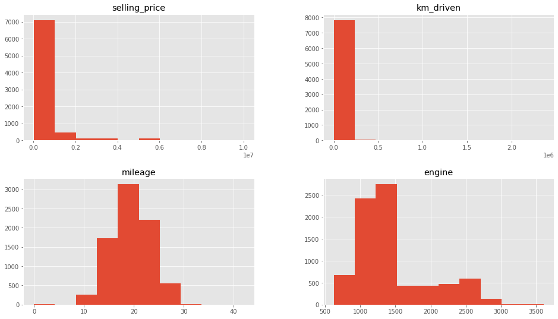

```python
Var_cons2.hist()
plt.show()
```

[output not shown]

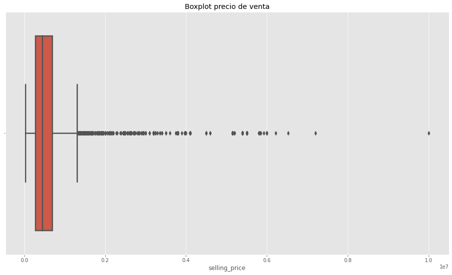

```python
sb.boxplot(Var_cons2["selling_price"],linewidth=2.5)
plt.title("Boxplot precio de venta")
```

[output not shown]

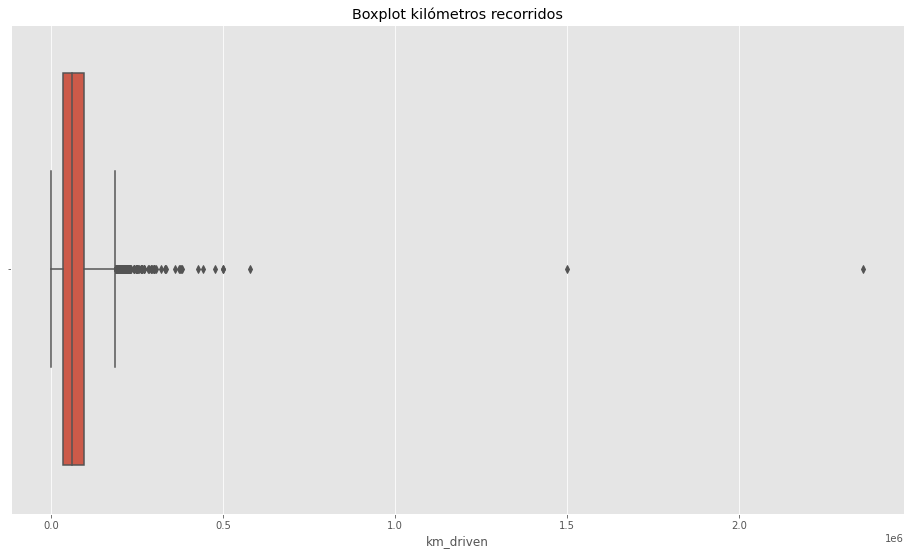

```python
sb.boxplot(Var_cons2["km_driven"])
plt.title("Boxplot kilómetros recorridos")
```

[output not shown]

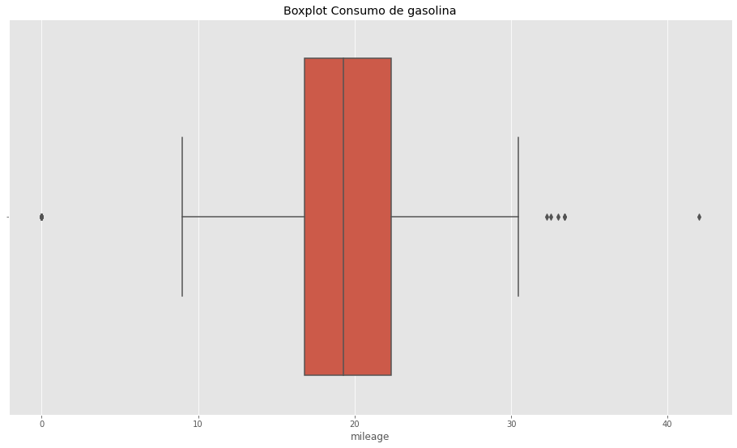

```python
sb.boxplot(Var_cons2["mileage"])
plt.title("Boxplot Consumo de gasolina")
```

[output not shown]

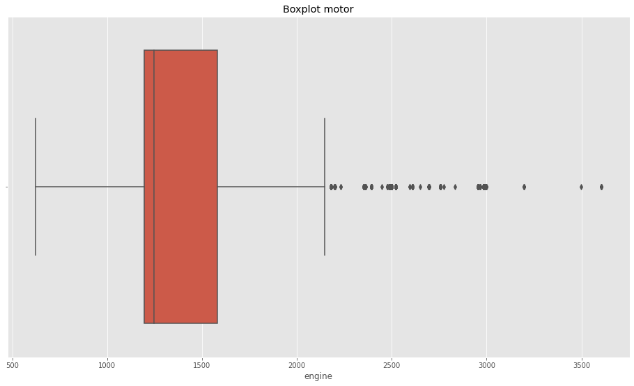

```python
sb.boxplot(Var_cons2["engine"])
plt.title("Boxplot motor")
```

Una vez realizados los gráficos, se procederá a realizar la construcción del modelo, en donde la variable respuesta será el precio de venta, y como variables explicativas, se considerarán el resto de las variables consideradas.

```python
dataX =Var_cons2[["km_driven","mileage","engine"]]
X_train = np.array(dataX)
y_train = Var_cons2['selling_price']

# Creamos el objeto de Regresión Linear
regr = linear_model.LinearRegression()

# Entrenamos nuestro modelo
regr.fit(X_train, y_train)

# Hacemos las predicciones que en definitiva una línea (en este caso, al ser 2D)
y_pred = regr.predict(X_train)

# Veamos los coeficienetes obtenidos, En nuestro caso, serán la Tangente
print('Coefficients: \n', regr.coef_)
# Este es el valor donde corta el eje Y (en X=0)
print('Independent term: \n', regr.intercept_)
# Error Cuadrado Medio
print("Mean squared error: %.2f" % mean_squared_error(y_train, y_pred))
# Puntaje de Varianza. El mejor puntaje es un 1.0
print('Variance score: %.2f' % r2_score(y_train, y_pred))
```

```
Coefficients:
 [-4.58286610e+00  3.58578101e+04  1.00754036e+03]
Independent term:
 -1199096.7355134818
Mean squared error: 441373644713.73
Variance score: 0.33
```

A continuación, se procederá a realizar el mismo modelo a través de otro método.

```python
X_train= sm.add_constant(X_train,prepend=True)
modelo = sm.OLS(endog=y_train,exog=X_train,)
modelo = modelo.fit()
print(modelo.summary())
```

```
                            OLS Regression Results
==============================================================================
Dep. Variable:          selling_price   R-squared:                       0.333
Model:                            OLS   Adj. R-squared:                  0.333
Method:                 Least Squares   F-statistic:                     1316.
Date:                Fri, 12 Mar 2021   Prob (F-statistic):               0.00
Time:                        21:58:19   Log-Likelihood:            -1.1723e+05
No. Observations:                7907   AIC:                         2.345e+05
Df Residuals:                    7903   BIC:                         2.345e+05
Df Model:                           3
Covariance Type:            nonrobust
==============================================================================
                 coef    std err          t      P>|t|      [0.025      0.975]
------------------------------------------------------------------------------
const      -1.199e+06   6.41e+04    -18.711      0.000   -1.32e+06   -1.07e+06
x1            -4.5829      0.135    -33.998      0.000      -4.847      -4.319
x2          3.586e+04   2269.584     15.799      0.000    3.14e+04    4.03e+04
x3          1007.5404     18.301     55.055      0.000     971.666    1043.414
==============================================================================
Omnibus:                     7003.309   Durbin-Watson:                   1.350
Prob(Omnibus):                  0.000   Jarque-Bera (JB):           292758.598
Skew:                           4.155   Prob(JB):                         0.00
Kurtosis:                      31.628   Cond. No.                     7.68e+05
==============================================================================

Notes:
[1] Standard Errors assume that the covariance matrix of the errors is correctly specified.
[2] The condition number is large, 7.68e+05. This might indicate that there are
strong multicollinearity or other numerical problems.
```

En donde se puede observar que el modelo de regresión lineal múltiple propuesto para este caso es:

$$ \hat{\text{selling_price}_i}=-1199096.735513485-4.58286610\text{km_driven}_i+35860\text{mileage}_i+1007.5404 \text{engine}_i $$

A pesar de que las variables son significativas, explican en tan solo un 33% a la variable respuesta. Además pueden exitir problemas de multicolinearidad, es decir, relación entre variables explicativas.

## Conclusiones

A través del presente ensayo, se trató de abordafr en general la regresión lineal, en donde se tocaron temas tanto teóricos como prácticos.

Además, se construyeron modelos de regresión a través de diferentes métodos, obteniendo los mismos resultados, a pesar de que los resultados no hayan sido los deseados.